# Using machine learning to dicriminate lncRNA and protein coding transcripts

## An example using R and caret

### Step 0. Setup

I’ve pre-made a dataset of lncRNA and protein coding transcripts from Gencodev27. The code to recreate it is [here](https://github.com/betsig/ML_caret_example/blob/master/create_lncRNA_pcRNA_dataset.R), but because it can take a while to extract features for each transcript, you can download it from [here](https://www.dropbox.com/s/8lxgmx9ojggdqv8/lncRNA_v_pcRNA.csv?dl=0).

First, load the packages you’ll need for later steps, and set up your environment

```r
library(caret)
```

```r
library(PRROC)
library(ggplot2)
library(pheatmap)

options(stringsAsFactors = FALSE)
options(warn = -1)
```

Next, read in the data

```r
lncRNAandpcRNA <- read.csv('lncRNA_v_pcRNA.csv')
head(lncRNAandpcRNA)
```

```
##   frame seq_length_nt seq_length start_site_nt start_site stop_site_nt
## 1     2          1103        367             2          1          698
## 2     2          2756        918           467        156         1304
## 3     1          2056        685             1          1         1285
## 4     2          3732       1243           185         62         1568
## 5     1          4732       1577             1          1         1744
## 6     2          2176        725            38         13         1367
##   stop_site orf_length utr3_length     APOS     CPOS     GPOS     TPOS
## 1       232        231         406 1.782609 1.528090 1.217822 1.492308
## 2       434        278        1453 1.017391 1.270270 1.200000 1.103306
## 3       428        427         772 1.717172 1.211429 1.511494 1.555556
## 4       522        460        2165 1.319549 1.093960 1.426295 1.169675
## 5       581        580        2989 1.538793 1.297030 1.341270 1.443038
## 6       455        442         810 1.037383 1.216667 1.442177 1.411392
##   GC_percent A_count C_count G_count T_count first_nt random_X  random_Y
## 1  0.6092475     198     330     342     233        A     4755 11.854338
## 2  0.4746009     697     612     696     751        C     9673  8.732710
## 3  0.6250000     384     598     687     387        G     7528 12.055251
## 4  0.5107181     929     942     964     897        G     4372  8.553038
## 5  0.5680473     929    1387    1301    1115        A     9487 10.226707
## 6  0.4264706     657     408     520     591        C     9564  8.594964
##     set
## 1 pcRNA
## 2 pcRNA
## 3 pcRNA
## 4 pcRNA
## 5 pcRNA
## 6 pcRNA
```

### Step 1: Data preprocesing

Create dummy variables so all your variables are now numeric

```r
# create dummy variables
dummies <- caret::dummyVars(set ~. , lncRNAandpcRNA)
# convert to dummy variables
all_data_numeric <- predict(dummies, newdata = lncRNAandpcRNA)
# original discrete variable
head(lncRNAandpcRNA[,c(22, grep("first_nt", colnames(lncRNAandpcRNA)))])
```

```
##     set first_nt
## 1 pcRNA        A
## 2 pcRNA        C
## 3 pcRNA        G
## 4 pcRNA        G
## 5 pcRNA        A
## 6 pcRNA        C
```

```r
# new numeric variables
head(all_data_numeric[,grep("first_nt", colnames(all_data_numeric))])
```

```
##   first_ntA first_ntC first_ntG first_ntT
## 1         1         0         0         0
## 2         0         1         0         0
## 3         0         0         1         0
## 4         0         0         1         0
## 5         1         0         0         0
## 6         0         1         0         0
```

Find any variables with near zero variance and remove them

```r
# find any variables with near zero variance
nzv <- nearZeroVar(all_data_numeric, saveMetrics=TRUE)
# in our case, there are none
if(any(nzv$nzv)){
  all_data_numeric <- all_data_numeric[,-which(nzv$nzv)]
}
```

Find any variable correlations and remove them

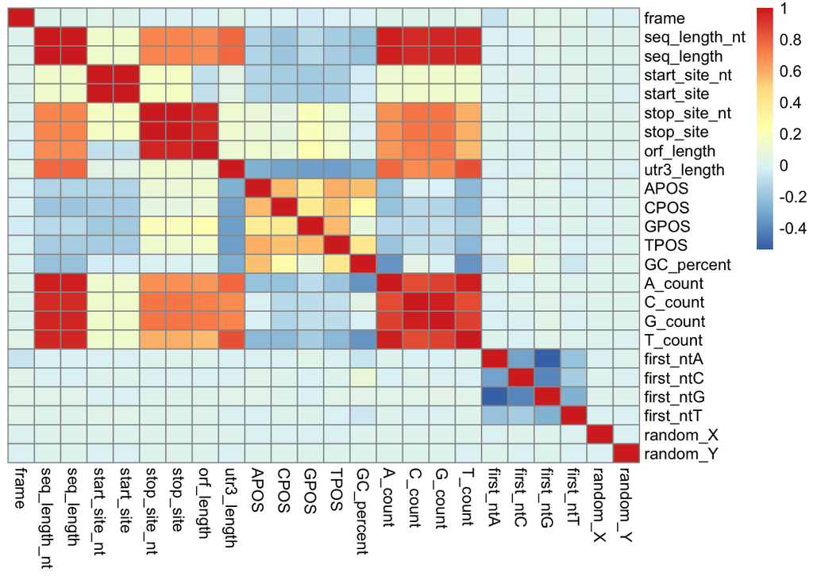

```r
# find any correlated variables
variable_correlations <- cor(all_data_numeric)
# heatmap of variable correlations
pheatmap(variable_correlations, cluster_rows = F, cluster_cols = F)
```

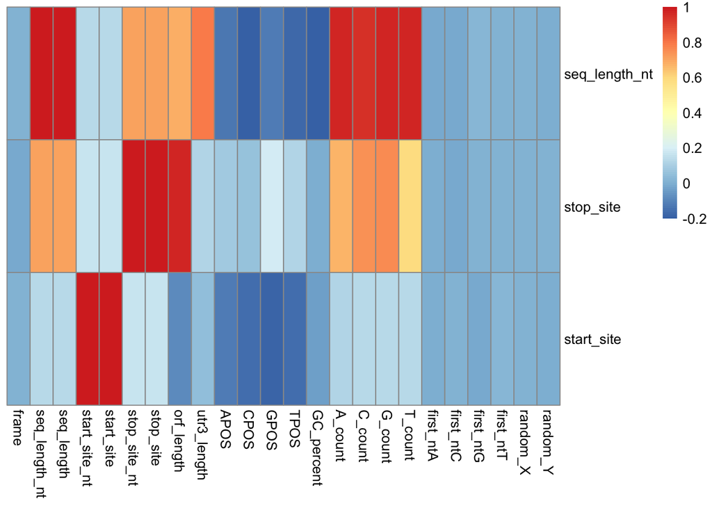

```r
# find correlations which are greater than 99%
highly_correlated <- findCorrelation(variable_correlations, cutoff = .99)

# we have 3 variables highly correlated to another
# in all these cases, it's nt lengths correlated to AA lengths (by definition, nt length = 3x AA length)
# e.g. seq_length_nt is correlated to seq_length (in AA) - as expected it's 3x translated AA length
pheatmap(variable_correlations[highly_correlated,], cluster_rows = F, cluster_cols = F)
```

```r
# remove these variables
all_data_numeric <- all_data_numeric[,-highly_correlated]
```

### Step 2: Data splitting, centering and scaling

We need to split up our data into 3 sets - training, testing and validation

```r
# set seed so this is reproducable
set.seed(1)

# reorder our rows randomly
random_order_pcRNA <- sample(which(lncRNAandpcRNA$set == "pcRNA"))
random_order_lncRNA <- sample(which(lncRNAandpcRNA$set == "lncRNA"))

# get indicies for balanced datasets (2000 in each set, at a 1:1 ratio)
inTrain <- c(random_order_pcRNA[1:1000], random_order_lncRNA[1:1000])
inValidate <- c(random_order_pcRNA[1001:2000], random_order_lncRNA[1001:2000])
inTest <- c(random_order_pcRNA[2001:3000], random_order_lncRNA[2001:3000])

# split our numeric data
training <- all_data_numeric[inTrain,]
validate <- all_data_numeric[inValidate,]
testing <- all_data_numeric[inTest,]
```

Center and scale our data

```r
# center and scale each dataset by the training values
preProcessValues <- preProcess(training, method=c("center", "scale"))
training <- predict(preProcessValues, training)
validate <- predict(preProcessValues, validate)
testing <- predict(preProcessValues, testing)

# add classes
train_class <- lncRNAandpcRNA$set[inTrain]
validate_class <- lncRNAandpcRNA$set[inValidate]
test_class <- lncRNAandpcRNA$set[inTest]

training <- cbind(as.data.frame(training), set=train_class)
validate <- cbind(as.data.frame(validate), set=validate_class)
testing <- cbind(as.data.frame(testing), set=test_class)
```

### Step 3: Model training

#### Part 1: Train with a selection of model algorithms

We’re going to train 5 different model types.

```r
# create a cross-validation control object
fitControl <- trainControl(## 10-fold CV
  method = "repeatedcv",
  number = 10, # 10 folds
  repeats = 3, # repeated 3 times
  classProbs = TRUE # allows us to get probabilities for class predictions
  )

# Random Forest (takes a while...)
randomForestModel <- train(set ~ .,
                      data=training,
                      method="rf",
                      trControl = fitControl,
                      verbose=FALSE)
# gradient boosting ensemble
boostModel <- train(set ~ .,
                     data=training,
                     method="gbm",
                     verbose=FALSE, # be quiet
                     trControl = fitControl)
# generalised linear model
linearModel <- train(set ~ .,
                    data=training,
                    method="glm",
                    trControl = fitControl)
# CART tree
treeModel <- train(set ~ .,
                     data=training,
                     method="rpart",
                     trControl = fitControl)

# Support Vector Machine (with rbf kernal)
svmModel <- train(set ~ .,
                   data=training,
                   method="svmRadial",
                   trControl = fitControl)
```

Next, we want to see how well each of these models performs on our testing data.

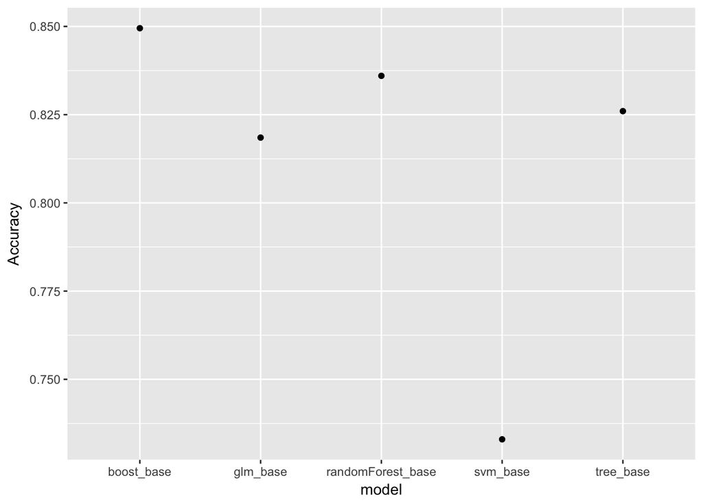

```r
# get each model to predict classes on our testing dataset
p_rF <- predict(randomForestModel, testing)
p_l <- predict(linearModel, testing)
p_b <- predict(boostModel, testing)
p_t <- predict(treeModel, testing)
p_s <- predict(svmModel, testing)

# calulcate performance metrics with confusion matrices
cf_rF <- confusionMatrix(p_rF,testing$set)
cf_l <- confusionMatrix(p_l,testing$set)
cf_b <- confusionMatrix(p_b,testing$set)
cf_t <- confusionMatrix(p_t,testing$set)
cf_s <- confusionMatrix(p_s,testing$set)

# create a summary data.frame for plotting
confusion_matrix_summary <- data.frame(randomForest=c(cf_rF$overall, cf_rF$byClass),
                                       glm=c(cf_l$overall, cf_l$byClass),
                                       boost=c(cf_b$overall, cf_b$byClass),
                                       tree=c(cf_t$overall, cf_t$byClass),
                                       svm=c(cf_s$overall, cf_s$byClass))


confusion_matrix_summary <- as.data.frame(t(confusion_matrix_summary))
confusion_matrix_summary$model <- paste0(rownames(confusion_matrix_summary), "_base")


# Check out accuracy for each model
ggplot(confusion_matrix_summary, aes(x=model, y=Accuracy)) + geom_point()
```

So it looks like our ‘best’ model is a ‘gbm’ (boost_base), however because this model has built in feature selection (as do ‘rpart’ and ‘rf’), we can’t discount our non-feature selected models just yet.

#### Part 2: Feature Selection

Feature seleciton is an important step in training models. Some have it built in (check out the documentation for your model to see if this is the case), and others don’t. The support vector machine model doesn’t have built in feature selection, so we’ll do this step on it to try an improve perofrmance.

```r
# do some funky rearranging
training_part <- training[,-match('set', colnames(training))]
train_class <- training$set
# for some reason, feature selection methods like our class to be a numeric factor (YMMV)
train_class <- gsub("pcRNA", "0", train_class)
train_class <- gsub("lncRNA", "1", train_class)
train_class <- as.factor(train_class)

# try subsets of 1,2,3,4,5,10,15, and 20 variables
subsets <- c(1:5, 10, 15, 20)

# make a new control object for feature selection
# uses 'rfFuncs' for model testing - you can also use 'lmFuncs' (for linear models)
ctrl <- rfeControl(functions = rfFuncs,
                   method = "repeatedcv",
                   repeats = 3,
                   verbose = FALSE)

# set our random seed again
set.seed(2)
# do recursive feature selection (this can take a while)
rfProfile <- rfe(training_part, train_class,
                 sizes = subsets,
                 metric="Accuracy",
                 rfeControl = ctrl)

# looks like 20 variables is the 'best'
rfProfile
```

```
##
## Recursive feature selection
##
## Outer resampling method: Cross-Validated (10 fold, repeated 3 times)
##
## Resampling performance over subset size:
##
##  Variables Accuracy  Kappa AccuracySD KappaSD Selected
##          1   0.7610 0.5220    0.02793 0.05586
##          2   0.8100 0.6200    0.02093 0.04185
##          3   0.8035 0.6070    0.02022 0.04044
##          4   0.8115 0.6230    0.01698 0.03395
##          5   0.8178 0.6357    0.01680 0.03360
##         10   0.8315 0.6630    0.01930 0.03861
##         15   0.8350 0.6700    0.01943 0.03886
##         20   0.8377 0.6753    0.01755 0.03511        *
##         21   0.8340 0.6680    0.01793 0.03585
##
## The top 5 variables (out of 20):
##    orf_length, start_site_nt, stop_site_nt, TPOS, APOS
```

```r
# find out the order that recursive feature selection put our variables in
variable_order <- rfProfile$optVariables
variable_order
```

```
##  [1] "orf_length"    "start_site_nt" "stop_site_nt"  "TPOS"
##  [5] "APOS"          "C_count"       "seq_length"    "T_count"
##  [9] "G_count"       "A_count"       "utr3_length"   "GPOS"
## [13] "GC_percent"    "CPOS"          "first_ntC"     "first_ntG"
## [17] "random_X"      "first_ntA"     "first_ntT"     "frame"
```

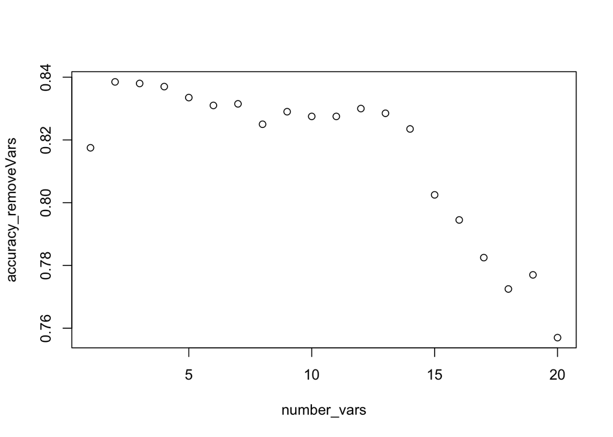

```r
# remove each variable 1 by 1, and see how much this imroves accuracy when we train a SVM
# NOTE: because we are trying to optimise here, we are using our validation set to get performance estimates.
confusion_matrix_list <- list()
for(i in 20:1){
  keep_vars <- c(variable_order[1:i], 'set')
  svmModel_feats <- train(set ~ .,
                  data=training[,keep_vars],
                  method="svmRadial",
                  trControl = fitControl)

  p_s <- predict(svmModel_feats, validate)
  confusion_matrix_list[[i]] <- confusionMatrix(p_s,validate$set)
}

accuracy_removeVars <- (unlist(lapply(confusion_matrix_list, function(x) x$overall[1])))
number_vars <- c(1:20)
plot(number_vars, accuracy_removeVars)
```

Now that we know what features are important for the best accuracy, let’s train a new model using only these features.

```r
# train a svm model with the 'best' features
keep_vars <- c(variable_order[1:which.max(accuracy_removeVars)], 'set')

svmModel_feats <- train(set ~ .,
                        data=training[,keep_vars],
                        method="svmRadial",
                        trControl = fitControl)

p_s <- predict(svmModel_feats, testing)
cf_sFeats <- confusionMatrix(p_s,testing$set)
# compare the old model (no feature selection) to the new model
cf_s # old
```

```
## Confusion Matrix and Statistics
##
##           Reference
## Prediction lncRNA pcRNA
##     lncRNA    591   125
##     pcRNA     409   875
##
##                Accuracy : 0.733
##                  95% CI : (0.713, 0.7523)
##     No Information Rate : 0.5
##     P-Value [Acc > NIR] : < 2.2e-16
##
##                   Kappa : 0.466
##  Mcnemar's Test P-Value : < 2.2e-16
##
##             Sensitivity : 0.5910
##             Specificity : 0.8750
##          Pos Pred Value : 0.8254
##          Neg Pred Value : 0.6815
##              Prevalence : 0.5000
##          Detection Rate : 0.2955
##    Detection Prevalence : 0.3580
##       Balanced Accuracy : 0.7330
##
##        'Positive' Class : lncRNA
##
```

```r
cf_sFeats # new
```

```
## Confusion Matrix and Statistics
##
##           Reference
## Prediction lncRNA pcRNA
##     lncRNA    819   146
##     pcRNA     181   854
##
##                Accuracy : 0.8365
##                  95% CI : (0.8196, 0.8525)
##     No Information Rate : 0.5
##     P-Value [Acc > NIR] : < 2e-16
##
##                   Kappa : 0.673
##  Mcnemar's Test P-Value : 0.06008
##
##             Sensitivity : 0.8190
##             Specificity : 0.8540
##          Pos Pred Value : 0.8487
##          Neg Pred Value : 0.8251
##              Prevalence : 0.5000
##          Detection Rate : 0.4095
##    Detection Prevalence : 0.4825
##       Balanced Accuracy : 0.8365
##
##        'Positive' Class : lncRNA
##
```

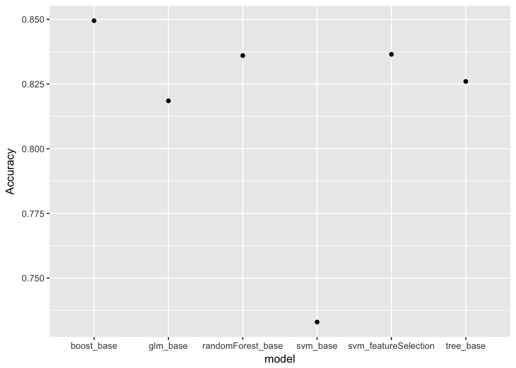

```r
# compare to all the previous models
newLine <- as.data.frame(t(data.frame(svm_featureSelection=c(cf_sFeats$overall, cf_sFeats$byClass))))
newLine$model <- "svm_featureSelection"
confusion_matrix_summary <- rbind(confusion_matrix_summary, newLine)
# now SVM has comparible performance to other models
ggplot(confusion_matrix_summary, aes(x=model, y=Accuracy)) + geom_point()
```

#### Part 3: Grid searches

Grid searches can be used for optimising hyperparameters in a model. We’ll be doing a (small) grid search for the hyperparamters (C/cost and sigma) in our SVM model.

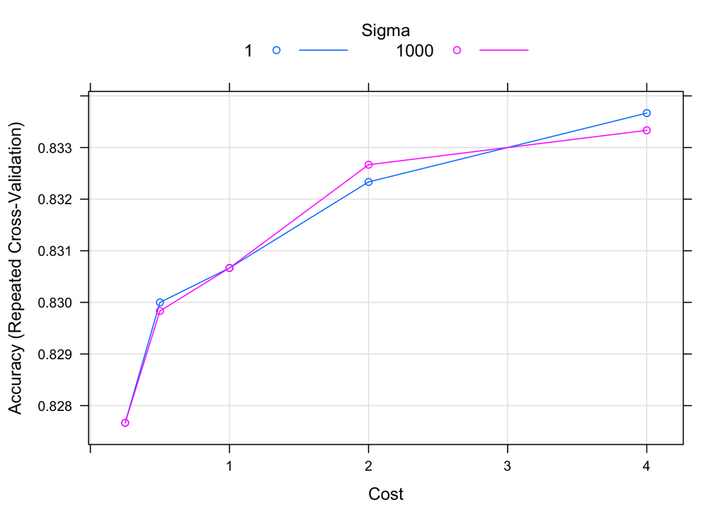

```r
# create a grid of values to test with
# (I've kept it small to save time)
svmGrid <-  expand.grid(C=c(0.25,0.50,1,2,4),
                        sigma = c(1, 1000))

svmModel_grid_featSel <- train(set ~ .,
                         data=training[,keep_vars],
                         method="svmRadial",
                         trControl = fitControl,
                         verbose=TRUE,
                         tuneGrid=svmGrid)

plot(svmModel_grid_featSel)
```

```r
grid_search_results <- svmModel_grid_featSel$results
grid_search_results[which.max(grid_search_results$Accuracy),]
```

```
##   C sigma  Accuracy     Kappa AccuracySD    KappaSD
## 9 4     1 0.8336667 0.6673333 0.01973677 0.03947355
```

Now that we know the optimal hyperparameters, lets train our model with them.

```r
# train a model with optimal hyperparameters

svmModel_grid_featSel <- train(set ~ .,
                         data=training[,keep_vars],
                         method="svmRadial",
                         trControl = fitControl,
                         verbose=TRUE,
                         tuneGrid=svmGrid[which.max(grid_search_results$Accuracy),-3])

p_s <- predict(svmModel_grid_featSel, testing)
cf_sGrid <- confusionMatrix(p_s,testing$set)
# compare the old model (with feature selection) to the new model
cf_sFeats # old
```

```
## Confusion Matrix and Statistics
##
##           Reference
## Prediction lncRNA pcRNA
##     lncRNA    819   146
##     pcRNA     181   854
##
##                Accuracy : 0.8365
##                  95% CI : (0.8196, 0.8525)
##     No Information Rate : 0.5
##     P-Value [Acc > NIR] : < 2e-16
##
##                   Kappa : 0.673
##  Mcnemar's Test P-Value : 0.06008
##
##             Sensitivity : 0.8190
##             Specificity : 0.8540
##          Pos Pred Value : 0.8487
##          Neg Pred Value : 0.8251
##              Prevalence : 0.5000
##          Detection Rate : 0.4095
##    Detection Prevalence : 0.4825
##       Balanced Accuracy : 0.8365
##
##        'Positive' Class : lncRNA
##
```

```r
cf_sGrid # new
```

```
## Confusion Matrix and Statistics
##
##           Reference
## Prediction lncRNA pcRNA
##     lncRNA    819   144
##     pcRNA     181   856
##
##                Accuracy : 0.8375
##                  95% CI : (0.8206, 0.8534)
##     No Information Rate : 0.5
##     P-Value [Acc > NIR] : < 2e-16
##
##                   Kappa : 0.675
##  Mcnemar's Test P-Value : 0.04583
##
##             Sensitivity : 0.8190
##             Specificity : 0.8560
##          Pos Pred Value : 0.8505
##          Neg Pred Value : 0.8255
##              Prevalence : 0.5000
##          Detection Rate : 0.4095
##    Detection Prevalence : 0.4815
##       Balanced Accuracy : 0.8375
##
##        'Positive' Class : lncRNA
##
```

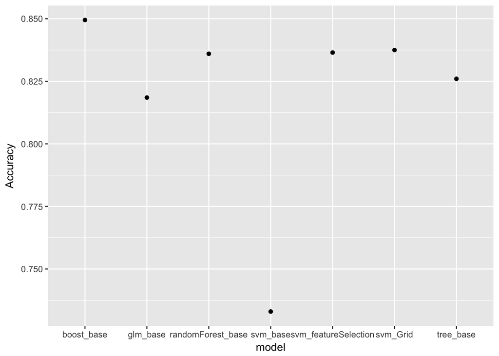

```r
# compare to all the previous models
newLine <- as.data.frame(t(data.frame(svm_Grid=c(cf_sGrid$overall, cf_sGrid$byClass))))
newLine$model <- "svm_Grid"
confusion_matrix_summary <- rbind(confusion_matrix_summary, newLine)
# not a huge jump in accuracy, as the original model hyperparameters were pretty close to the optimal ones already
ggplot(confusion_matrix_summary, aes(x=model, y=Accuracy)) + geom_point()
```

### Working with unbalanced data

When applying ML to genetics problems, we often are working with unbalanced datasets. We’ll use the same lncRNA / pcRNA dataset, but now at a 1:6 ratio to test out some methods that can be useful.

#### Step 1. Set up an unbalanced dataset

```r
# get indicies for unbalanced datasets (at a 1:6 ratio for testing and validation)
# 500:3000 for testing and validation
# remainder of pcRNA in training
# still using the same order as before, so there shouldn't be any cross contamination
inTrain <- c(random_order_pcRNA[1:1000], random_order_lncRNA[1:1000], random_order_pcRNA[7000:length(random_order_pcRNA)])
inValidate <- c(random_order_pcRNA[1001:2000], random_order_lncRNA[1001:1500], random_order_pcRNA[3001:5000])
inTest <- c(random_order_pcRNA[2001:3000], random_order_lncRNA[2001:2500], random_order_pcRNA[5001:7000])
```

#### Step 2. Preprocess

Same steps as when we were processing the balanced dataset.

```r
# split our numeric data
training <- all_data_numeric[inTrain,]
validate <- all_data_numeric[inValidate,]
testing <- all_data_numeric[inTest,]

# center and scale each dataset by the training values
preProcessValues <- preProcess(training, method=c("center", "scale"))
training <- predict(preProcessValues, training)
validate <- predict(preProcessValues, validate)
testing <- predict(preProcessValues, testing)

# add classes
train_class <- lncRNAandpcRNA$set[inTrain]
validate_class <- lncRNAandpcRNA$set[inValidate]
test_class <- lncRNAandpcRNA$set[inTest]

training <- cbind(as.data.frame(training), set=train_class)
validate <- cbind(as.data.frame(validate), set=validate_class)
testing <- cbind(as.data.frame(testing), set=test_class)
```

#### Step 3. Model Training

**Part 1. The base model**

First, let’s build a model with the same ratio of lncRNA:pcRNA as we are iusing in the testing dataset. We’re going to be training ‘gbm’ models as they’re a bit faster to train, and don’t require feature selection.

```r
# we're using a small subset of the data here (200/1000 lncRNAs) to speed up how fast this runs.
# NOTE: if you're using random subsets, remember to replicate models and take the average performance to compare to other models.
set.seed(3)
train_index_1 <- sample(which(training$set == "lncRNA"), 200)
train_index_2 <- sample(which(training$set == "pcRNA"), 200*6)

training_part <- training[(c(train_index_1, train_index_2)),]

# we're using a gradient boosting machine algorithm this time
# it has built in feature selection, so we dont need to worry about that step
# and it runs pretty fast
boostModel_unbalanced <- train(set ~ .,
                      data=training_part,
                      method="gbm",
                      verbose=FALSE,
                      trControl = fitControl)

p_b_unbal <- predict(boostModel_unbalanced, testing)
conf_unbal <- confusionMatrix(p_b_unbal, testing$set)
# our model has fairly high specificity, positive predictive value, negative predictive value, and accuracy
# but low sensitivity (we're incorrectly classing a lot of our lncRNAs as protein coding)
conf_unbal
```

```
## Confusion Matrix and Statistics
##
##           Reference
## Prediction lncRNA pcRNA
##     lncRNA    304   129
##     pcRNA     196  2871
##
##                Accuracy : 0.9071
##                  95% CI : (0.897, 0.9166)
##     No Information Rate : 0.8571
##     P-Value [Acc > NIR] : < 2.2e-16
##
##                   Kappa : 0.5984
##  Mcnemar's Test P-Value : 0.0002512
##
##             Sensitivity : 0.60800
##             Specificity : 0.95700
##          Pos Pred Value : 0.70208
##          Neg Pred Value : 0.93609
##              Prevalence : 0.14286
##          Detection Rate : 0.08686
##    Detection Prevalence : 0.12371
##       Balanced Accuracy : 0.78250
##
##        'Positive' Class : lncRNA
##
```

```r
# our F1 is also not great in comparison to the rest of our metrics
conf_unbal$byClass['F1']
```

```
##        F1
## 0.6516613
```

**Part 2. Adding weights**

Weights can be added to each example in our training dataset to determine how heavily it should be weighted during the process of training.

```r
# add weights to each training instance
model_weights <- ifelse(training_part$set == "lncRNA",
                       (1/table(training_part$set)[1]) * 0.5,
                       (1/table(training_part$set)[2]) * 0.5)

# lncRNAs have higher weights than pcRNA
table(model_weights, training_part$set)
```

```
##
## model_weights          lncRNA pcRNA
##   0.000416666666666667      0  1200
##   0.0025                  200     0
```

```r
boostModel_weights <- train(set ~ .,
                          data=training_part,
                          method="gbm",
                          weights=model_weights,
                          verbose=FALSE,
                          trControl = fitControl)

p_b_weights <- predict(boostModel_weights, testing)
conf_weights <- confusionMatrix(p_b_weights, testing$set)

# now we're moving in the right direction!
# our weighted model has much better sensitivity
conf_weights
```

```
## Confusion Matrix and Statistics
##
##           Reference
## Prediction lncRNA pcRNA
##     lncRNA    393   390
##     pcRNA     107  2610
##
##                Accuracy : 0.858
##                  95% CI : (0.846, 0.8694)
##     No Information Rate : 0.8571
##     P-Value [Acc > NIR] : 0.4542
##
##                   Kappa : 0.5308
##  Mcnemar's Test P-Value : <2e-16
##
##             Sensitivity : 0.7860
##             Specificity : 0.8700
##          Pos Pred Value : 0.5019
##          Neg Pred Value : 0.9606
##              Prevalence : 0.1429
##          Detection Rate : 0.1123
##    Detection Prevalence : 0.2237
##       Balanced Accuracy : 0.8280
##
##        'Positive' Class : lncRNA
##
```

```r
conf_unbal
```

```
## Confusion Matrix and Statistics
##
##           Reference
## Prediction lncRNA pcRNA
##     lncRNA    304   129
##     pcRNA     196  2871
##
##                Accuracy : 0.9071
##                  95% CI : (0.897, 0.9166)
##     No Information Rate : 0.8571
##     P-Value [Acc > NIR] : < 2.2e-16
##
##                   Kappa : 0.5984
##  Mcnemar's Test P-Value : 0.0002512
##
##             Sensitivity : 0.60800
##             Specificity : 0.95700
##          Pos Pred Value : 0.70208
##          Neg Pred Value : 0.93609
##              Prevalence : 0.14286
##          Detection Rate : 0.08686
##    Detection Prevalence : 0.12371
##       Balanced Accuracy : 0.78250
##
##        'Positive' Class : lncRNA
##
```

```r
conf_weights$byClass['F1']
```

```
##        F1
## 0.6126267
```

**Part 3. Under and Over-sampling**

We can also use under and oversampling to determine the best ratio that our data should be in for training. Often, this is not the same ratio as the testing dataset.

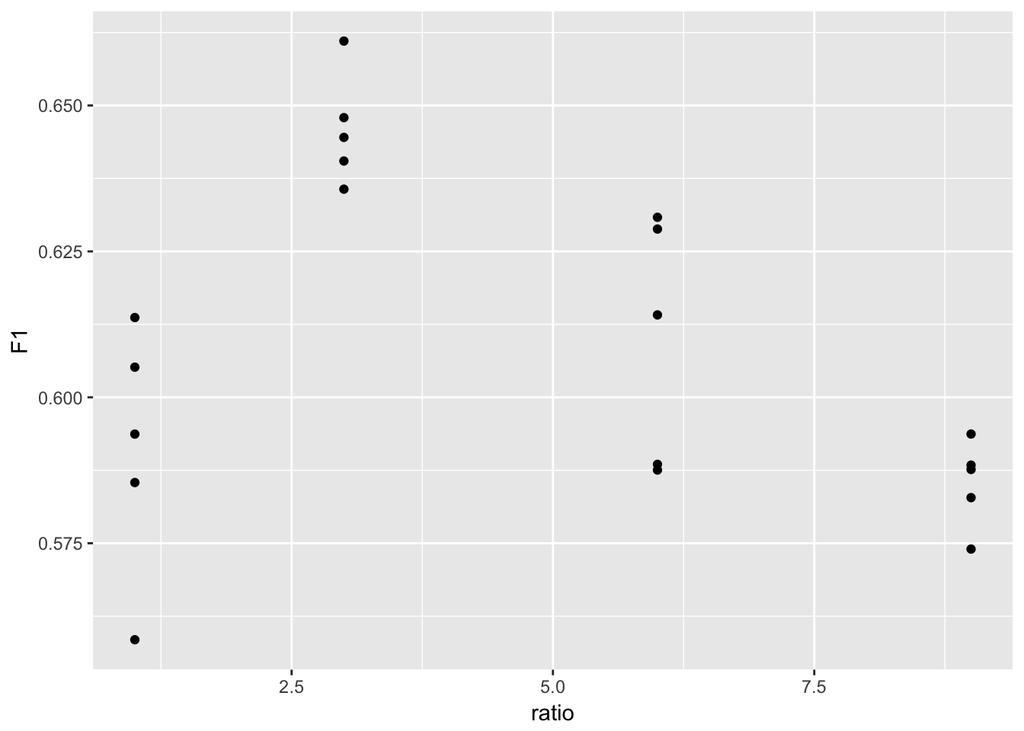

```r
# use ratios of 1:1, 1:3, 1:6, and 1:9
# repeat 5 times so we get a bit of a feel for variability
set.seed(5)
training_ratio <- rep(c(1,3,6,9), each=5)

confusion_matrix_list_ratio <- list()

for(t in 1:length(training_ratio)){
  fact <- training_ratio[t]

  train_index_1 <- sample(which(training$set == "lncRNA"), 200)
  train_index_2 <- sample(which(training$set == "pcRNA"), 200*fact)

  training_part <- training[(c(train_index_1, train_index_2)),]

  boostModel_ratio <- train(set ~ .,
                      data=training_part,
                      method="gbm",
                      verbose=FALSE,
                      trControl = fitControl)

  p_b <- predict(boostModel_ratio, validate)
  confusion_matrix_list_ratio[[t]] <- confusionMatrix(p_b,validate$set)
}

ratio_df <- data.frame(ratio=training_ratio,
                       Accuracy=(unlist(lapply(confusion_matrix_list_ratio, function(x) x$overall[1]))),
                       F1=(unlist(lapply(confusion_matrix_list_ratio, function(x) x$byClass['F1']))))

# peak F1 at a 3:1 ratio
ggplot(ratio_df, aes(x=ratio, y=F1)) + geom_point()
```

Now create a model using the optimal training ratio

```r
mean_F1 <- aggregate(F1 ~ ratio, ratio_df, mean)
best_ratio <- mean_F1$ratio[which.max(mean_F1$F1)]

train_index_1 <- sample(which(training$set == "lncRNA"), 500)
train_index_2 <- sample(which(training$set == "pcRNA"), 500*best_ratio)

training_part <- training[(c(train_index_1, train_index_2)),]

boostModel_ratio <- train(set ~ .,
                      data=training_part,
                      method="gbm",
                      verbose=FALSE,
                      trControl = fitControl)

p_b <- predict(boostModel_ratio, testing)

conf_ratio <- confusionMatrix(p_b,testing$set)

conf_ratio # with best ratio
```

```
## Confusion Matrix and Statistics
##
##           Reference
## Prediction lncRNA pcRNA
##     lncRNA    349   181
##     pcRNA     151  2819
##
##                Accuracy : 0.9051
##                  95% CI : (0.895, 0.9147)
##     No Information Rate : 0.8571
##     P-Value [Acc > NIR] : <2e-16
##
##                   Kappa : 0.6221
##  Mcnemar's Test P-Value : 0.1115
##
##             Sensitivity : 0.69800
##             Specificity : 0.93967
##          Pos Pred Value : 0.65849
##          Neg Pred Value : 0.94916
##              Prevalence : 0.14286
##          Detection Rate : 0.09971
##    Detection Prevalence : 0.15143
##       Balanced Accuracy : 0.81883
##
##        'Positive' Class : lncRNA
##
```

```r
conf_unbal$byClass['F1'] # same test/train ratio
```

```
##        F1
## 0.6516613
```

```r
conf_ratio$byClass['F1'] # best ratio
```

```
##        F1
## 0.6776699
```

#### Performance metrics for unbalanced classes

You may want to use a metric other than accuracy to evaluate how well your classifier works on an unbalanced dataset.

Reciever Operator Characteristic (ROC) curves are independant of test set balancing

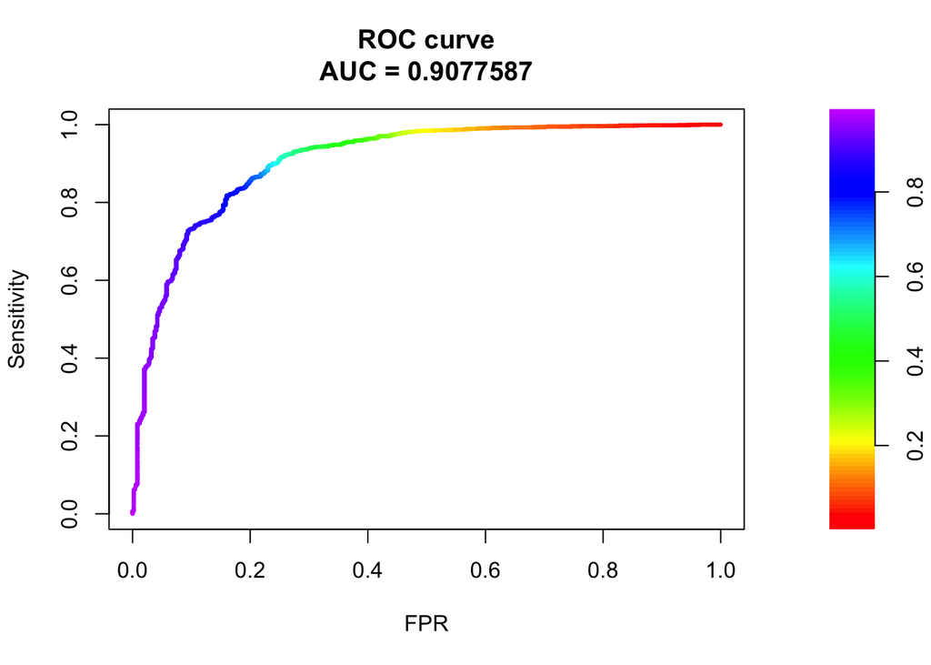

```r
# at 6:1 ratio
prob_b <- predict(boostModel_ratio, testing, "prob")
roc.6 <- roc.curve(scores.class0 = prob_b[testing$set=="pcRNA",2],
                   scores.class1 = prob_b[testing$set=="lncRNA",2], curve=TRUE)
plot(roc.6)
```

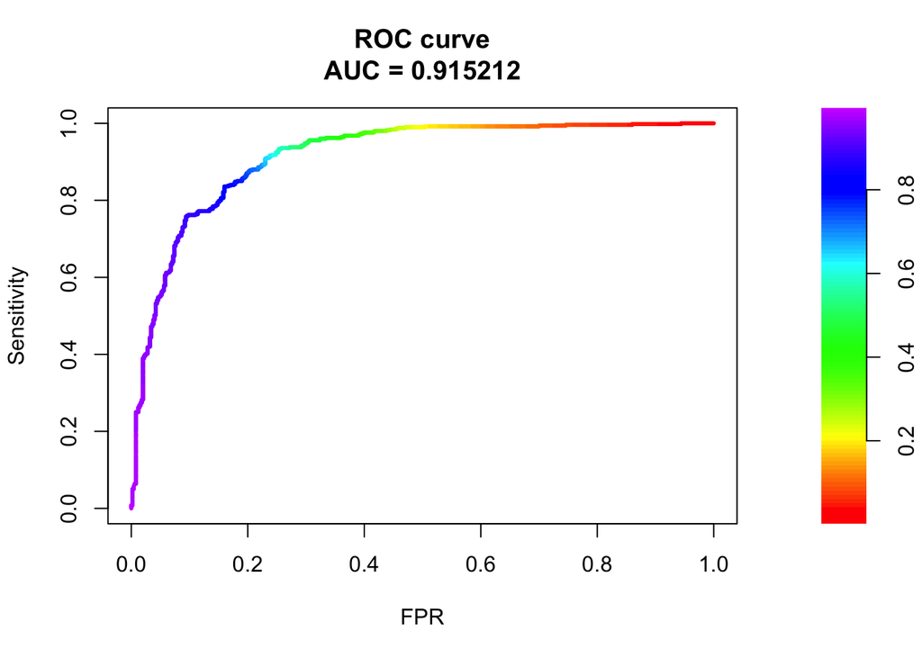

```r
# at 1:1 ratio
roc.1 <- roc.curve(scores.class0 = prob_b[testing$set=="pcRNA",2][sample(1:3000, 500)],
                   scores.class1 = prob_b[testing$set=="lncRNA",2], curve=TRUE)
plot(roc.1)
```

While Precision Recall curves can be useful for understanding how well your model performs on positive data, they are not independant of test dataset ratio composition.

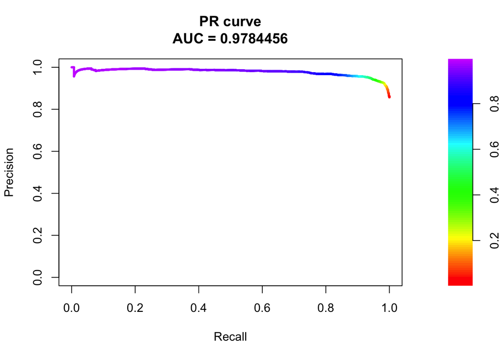

```r
# at 6:1 ratio
pr.6 <- pr.curve(scores.class0 = prob_b[testing$set=="pcRNA",2],
                   scores.class1 = prob_b[testing$set=="lncRNA",2], curve=TRUE)
plot(pr.6)
```

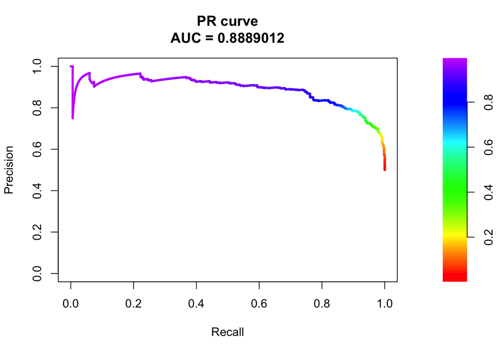

```r
# at 1:1 ratio
pr.1 <- pr.curve(scores.class0 = prob_b[testing$set=="pcRNA",2][sample(1:3000, 500)],
                   scores.class1 = prob_b[testing$set=="lncRNA",2], curve=TRUE)
plot(pr.1)
```

### Feature Importance

Often we want to know why a model works, and with more complex algorithms this can be quite difficult. If we’re using simple models, we can often take a look at the decisions the model is making.

For a tree-based model, we can just plot it:

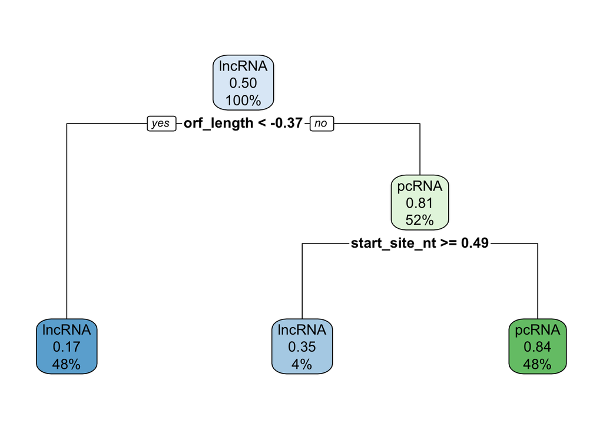

```r
library(rpart.plot)
# remember that our variables are sentered and scaled
rpart.plot(treeModel$finalModel)
```

Knowing what features are heavily contributing to model predictions can give us some insight when using more complex models.

```r
varImp(boostModel)
```

```
## gbm variable importance
##
##   only 20 most important variables shown (out of 21)
##
##                 Overall
## orf_length    100.00000
## start_site_nt  21.08442
## TPOS            6.88258
## APOS            4.96024
## GPOS            4.03773
## GC_percent      3.57158
## utr3_length     3.32185
## C_count         3.20453
## G_count         3.01204
## T_count         2.66826
## A_count         2.06407
## seq_length      1.97005
## random_X        1.58536
## CPOS            1.50160
## random_Y        0.70833
## stop_site_nt    0.58796
## first_ntC       0.30393
## first_ntA       0.13276
## first_ntG       0.09329
## first_ntT       0.00000
```

In the case of the boosted model, ORF length is the top feature for classifying datapoints. This makes sense as protein coding transcripts tend to have long open reading frames, wheras lncRNAs tend not to.

We can also see that some of the random features (random_X and random_Y) are more important than some of the real features, which can give us an idnication that they might not be very important for model performance. I’ve incuded these to show that variable importance is not bulletproof.

**Leave-one-out model training**

We can also retrain models without each variable to see which variables have a large impact on model performance

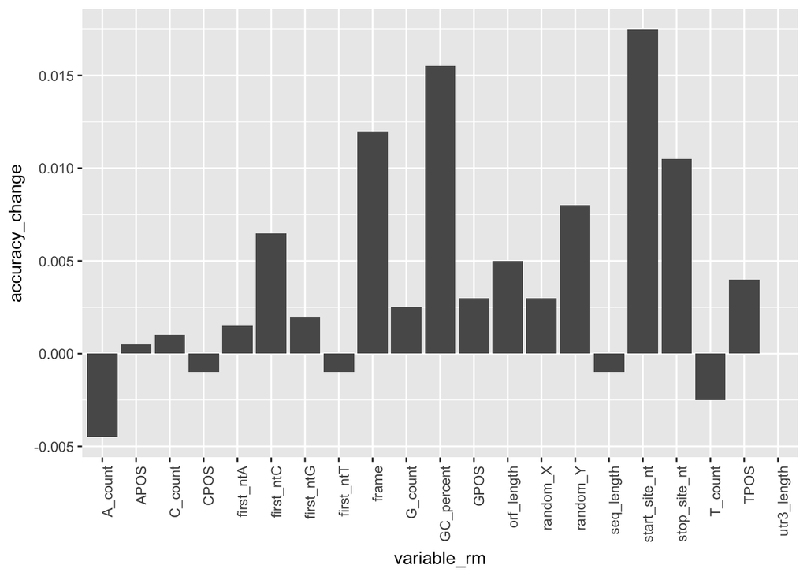

```r
all_data_numeric <- predict(dummies, newdata = lncRNAandpcRNA)

# remove correlated variables
variable_correlations <- cor(all_data_numeric)
all_data_numeric <- all_data_numeric[,-highly_correlated]

# get indicies for balanced datasets (2000 in each set, at a 1:1 ratio)
inTrain <- c(random_order_pcRNA[1:1000], random_order_lncRNA[1:1000])
inTest <- c(random_order_pcRNA[2001:3000], random_order_lncRNA[2001:3000])

# split our numeric data
training <- all_data_numeric[inTrain,]
testing <- all_data_numeric[inTest,]

preProcessValues <- preProcess(training, method=c("center", "scale"))
training <- predict(preProcessValues, training)
testing <- predict(preProcessValues, testing)

# add classes
train_class <- lncRNAandpcRNA$set[inTrain]
test_class <- lncRNAandpcRNA$set[inTest]

training <- cbind(as.data.frame(training), set=train_class)
testing <- cbind(as.data.frame(testing), set=test_class)

# get a vector of all or training variables
variables <- colnames(training)
variables <- variables[-which(variables=="set")]

confusion_matrix_list_L10 <- list()
for(var in seq_along(variables)){
  rm <- which(colnames(training) == variables[var])

  boostModel_L1O <- train(set ~ .,
                     data=training[,-rm],
                     method="gbm",
                     verbose=FALSE, # be quiet
                     trControl = fitControl)

  p_L10 <- predict(boostModel_L1O, testing[,-rm])
  confusion_matrix_list_L10[[var]] <- confusionMatrix(p_L10, testing$set)
}

confusion_matrix_summary_L1O <- data.frame(variable_rm = variables,
                                           accuracy=unlist(lapply(confusion_matrix_list_L10, function(x) x$overall['Accuracy'])),
                                           F1=unlist(lapply(confusion_matrix_list_L10, function(x) x$byClass['F1']))
                                           )
confusion_matrix_summary_L1O$accuracy_change <- cf_b$overall['Accuracy'] - confusion_matrix_summary_L1O$accuracy
confusion_matrix_summary_L1O$F1_change <- cf_b$byClass['F1'] - confusion_matrix_summary_L1O$F1

# Check out accuracy change for each model
ggplot(confusion_matrix_summary_L1O, aes(x=variable_rm, y=accuracy_change)) +
  geom_bar(stat="identity") + theme(axis.text.x=element_text(angle=90,hjust=1))
```

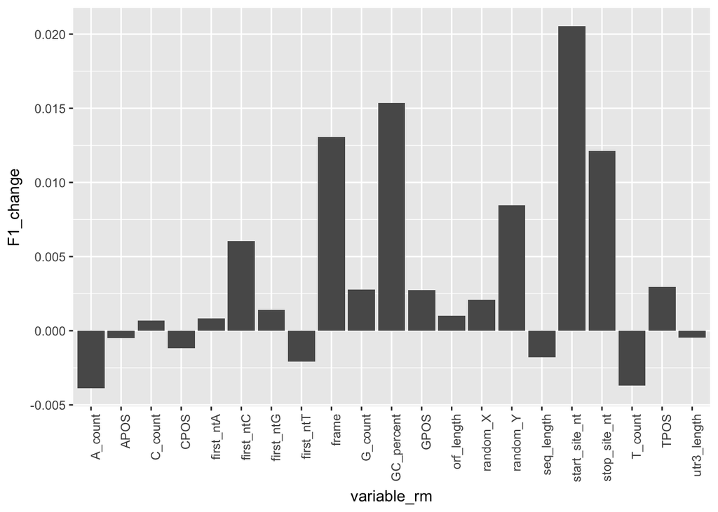

```r
# Check out F1 change for each model
ggplot(confusion_matrix_summary_L1O, aes(x=variable_rm, y=F1_change)) +
  geom_bar(stat="identity") + theme(axis.text.x=element_text(angle=90,hjust=1))
```

In most cases, the change in accuracy and F1 is not very big, but there are a few variables where removal actually increases model accuracy. For these, it’s unlikely that they are important for predictions.